# foss4gna-gdalraster

## GDAL API Bindings for R

https://firelab.github.io/gdalraster/

**Chris Toney** (@ctoney)  
USDA Forest Service, Rocky Mountain Research Station

**Michael D. Sumner**  
Australian Antarctic Division

*Logo designed by* **Sylvain Beorchia**

## R package `gdalraster`

### `osgeo`-like bindings + custom tools

- GDAL **Raster and Vector** Data Models
- Modularized, low-level access to GDAL objects
- Thin layer of abstraction over `Driver`, `Dataset`, `RasterBand`, `OGRLayer`, `GDALAlgorithm`, …  
  → **`Rcpp` modules w/ C++ classes exposed in R**
- Safe object lifetimes
- ℹ️ **Extensive documentation built-in and online**

## Comprehensive API bindings

### → Raster and Vector APIs, plus:

- *GDAL’s modernized CLI framework*!
- GDAL traditional utilities
- Spatial reference systems and transformation (GDAL PROJ)
- Geometry API operating on WKB/WKT
- Virtual Systems Interface (VSI)
- Partial support for multidimensional raster
- **Custom tools** 🔧

## Installation

CRAN (incl. Windows and macOS binaries)

```r
install.packages("gdalraster")
```

conda-forge (release builds)

```bash
conda install --channel conda-forge r-gdalraster
```

GitHub

```r
remotes::install_github("firelab/gdalraster")
```

R-universe (dev builds)

```r
install.packages("gdalraster", repos = c("https://firelab.r-universe.dev", "https://cran.r-project.org"))
```

## Short overview/highlights of each

Raster

Vector

Spatial ref and transformation

Geometry API

Virtual file systems

Bindings to the GDAL CLI framework

# Raster Data Model

## Class `GDALRaster`

Holds a pointer to a raster `Dataset`

Constructor w/ optional args:

```r
ds <- new(GDALRaster, filename, read_only = TRUE, open_options = NULL, shared = TRUE)
```

Exposes methods of `Dataset` and `RasterBand`, e.g. …

```r
ds$info()
ds$getDriverShortName()
ds$getDriverLongName()
ds$getRasterXSize()
ds$getRasterYSize()
ds$getRasterCount()
ds$addBand(dataType, options)
ds$getGeoTransform()
ds$setGeoTransform(transform)
ds$getProjection()
ds$setProjection(projection)
```

```r
ds$getDescription(band)
ds$setDescription(band, desc)
ds$getBlockSize(band)
ds$getDataTypeName(band)
ds$getNoDataValue(band)
ds$setNoDataValue(band, value)
ds$deleteNoDataValue(band)
ds$getMetadata(band, dom)
ds$setMetadata(band, metadata, dom)
ds$getMaskFlags(band)
# many more...
```

## `GDALRaster` pixel I/O methods

- Wraps `GDALRasterIO()`
- Helpers to iterate on block boundaries, or user-defined multi-block chunks

```r
ds$get_block_indexing(band)
ds$make_chunk_index(band, max_pixels)

ds$read(band, xoff, yoff, xsize, ysize, out_xsize, out_ysize)
ds$readBlock(band, xblockoff, yblockoff)
ds$readChunk(band, chunk_def)

ds$write(band, xoff, yoff, xsize, ysize, rasterData)
ds$writeBlock(band, xblockoff, yblockoff, rasterData)
ds$writeChunk(band, chunk_def, rasterData)
```

## Raster creation techniques

- If the format driver supports: `gdal_formats()`
- Return a live dataset object  
  → *enables GDAL in-memory (MEM) format in R*
- Programmatic: `create()`, `createCopy()`
- Utilities: `translate()`, `warp()`, …
- **GDAL CLI algorithms**
  - API usage of the CLI framework operates on dataset objects, not just files

## No-copy MEM raster from R data

#### `rvector_to_MEM()`

- Expose pixel data in an existing R vector to GDAL
- Pointer to R’s underlying C array (writable)
- Safe object lifetimes

```r
v <- sample(0:255, 20, replace = TRUE)
(ds_mem <- rvector_to_MEM(v, xsize = 5, ysize = 4))
```

```
#> C++ object of class <GDALRaster>
#>   • Driver: In Memory Raster (MEM)
#>   • DSN: <data pointer>
#>   • Dimensions: 5, 4, 1
#>   • CRS: not set
#>   • Pixel resolution: 1.000000, 1.000000
#>   • Bbox: 0.000000, 0.000000, 5.000000, 4.000000
```

## Raster tools

- `autoCreateWarpedVRT()`
- `buildVRT()`
- `calc()`
- `combine()`
- `dem_proc()`
- `fillNodata()`
- `footprint()`
- `is_los_visible()`
- `make_chunk_index()`
- `polygonize()`
- `rasterize()`
- `sieveFilter()`
- `translate()`
- `warp()`
- `buildRAT()`
- `mdim_as_classic()`
- `pixel_extract()`
- `bandCopyWholeRaster()`
- `copyDatasetFiles()`
- `deleteDataset()`
- `inspectDataset()`
- `renameDataset()`

## Raster display

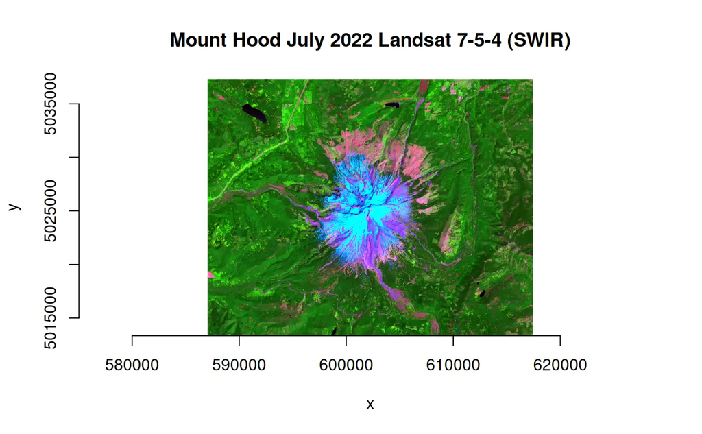

```r
read_ds(rast, bands = c(7, 5, 4)) |>
  plot_raster(
    minmax_pct_cut = c(2, 98),
    main = "Mount Hood July 2022 Landsat 7-5-4 (SWIR)")
```

## Raster Attribute Tables

#### Read/display/build/write

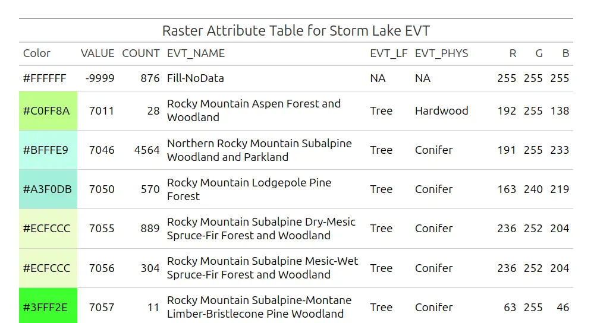

# Vector Data Model

## Feature-complete Vector API

- Dataset creation
- Test dataset/layer capabilities
- Complete schema management:
  - Layers and fields
  - Create/delete/rename
  - Read/write field domains
  - Execute SQL
- GDAL utilities: `ogrinfo()`, `ogr2ogr()`
- GDAL algorithms
  - Vector geoprocessing
- Vector display
- Persistent dataset connection
- Efficient I/O
- Attribute and spatial filters
- Write:
  - New features in a layer
  - Upsert
  - Edit/overwrite
  - Delete
- Transactions
- Arrow Array Stream read/write
- Create/append/inspect SOZip

## Class `GDALVector`

Pointers to one `OGRLayer` and its `Dataset`

Constructor w/ optional args:

```r
lyr <- new(GDALVector, dsn, layer, read_only, open_options, spatial_filter, dialect)
```

Exposes methods on `OGRLayer`, e.g. …

```r
lyr$getName()
lyr$getFieldNames()
lyr$testCapability()
lyr$getFIDColumn()
lyr$getGeomType()
lyr$getGeometryColumn()
lyr$getSpatialRef()
lyr$bbox()
lyr$getLayerDefn()
lyr$getFieldDomain(domain_name)
```

```r
lyr$setAttributeFilter(query)
lyr$getAttributeFilter()
lyr$setIgnoredFields(fields)
lyr$setSelectedFields(fields)
lyr$getIgnoredFields()
lyr$setSpatialFilter(wkt)
lyr$setSpatialFilterRect(bbox)
lyr$getSpatialFilter()
lyr$getFeatureCount()
# ...
```

## `GDALVector` I/O methods

- Traditional row iteration
- GDAL’s Arrow-based column-oriented API
- R-side `ArrowArrayStream` delivered by `nanoarrow`

```r
lyr$getNextFeature()
lyr$setNextByIndex(i)
lyr$getFeature(fid)
lyr$resetReading()

lyr$fetch(n)  # analog of DBI::dbFetch()

lyr$setFeature(feature)
lyr$createFeature(feature)
lyr$batchCreateFeature(feature_set)
lyr$upsertFeature(feature)
lyr$deleteFeature(fid)
```

```r
lyr$startTransaction()
lyr$commitTransaction()
lyr$rollbackTransaction()

lyr$getArrowStream()
lyr$releaseArrowStream()
lyr$writeArrowBatch(df)
```

[figure not shown]

## Vector read benchmarks

- NZ Building Outlines, 1.5 GB GeoPackage
- Load 3.3 million polygon features with 13 attributes each

| Method | Time (s) |
| --- | --- |
| *gdalraster* row-oriented → base R data frame | 11.2 |
| *gdalraster* row-oriented + convert to *sf* | 25.0 |
| *sf* row-oriented → *sf* data frame | 77.2 |
| *gdalraster* Arrow stream → base R data frame | 2.9 |
| *sf* Arrow stream → *sf* data frame | 11.2 |

https://firelab.github.io/gdalraster/articles/vector-read-benchmarks.html

# Spatial Reference System API

## Spatial reference and transformation

#### PROJ via GDAL Spatial Reference System API

- Set of `srs_*()`functions
  - Convert among SRS formats
  - Query attributes of an SRS definition
  - Query the PROJ database
- Transform coordinates, geometries, bounding boxes

# Geometry API

## Geometry API operating on WKB/WKT

#### GEOS via GDAL Geometry API

GEOS

- Flexibly operate on either WKB or WKT
  - Lists of WKB `raw` vectors or WKT strings
  - `g_wk2wk()`: auto convert one to the other
- `g_*()` functions: geom factory, inspect/test, binary predicates, binary ops, unary ops, measurements, utilities

## Geom API is convenient for interactive use and suitable for processing

#### Plotting uses the `wk` package

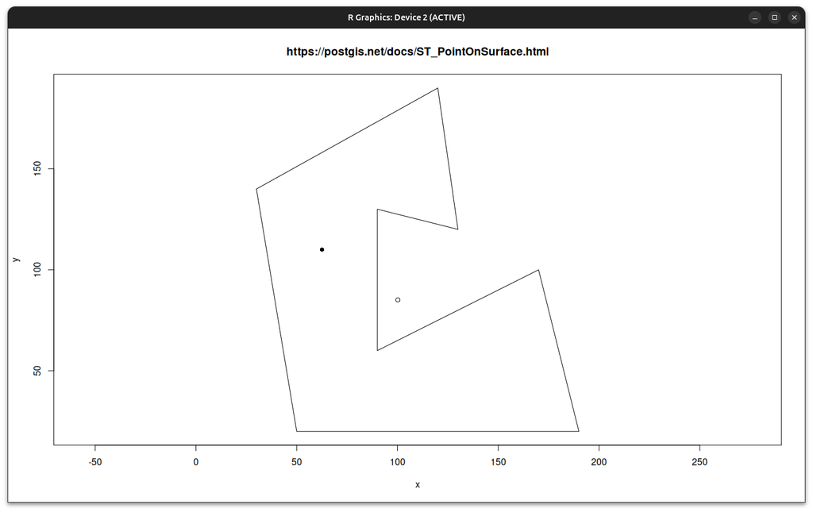

```r
# https://postgis.net/docs/ST_PointOnSurface.html
g <- "POLYGON ((130 120, 120 190, 30 140, 50 20, 190 20,
                170 100, 90 60, 90 130, 130 120))"
pt <- g_point_on_surface(g)
plot_geom(g, main = "https://postgis.net/docs/ST_PointOnSurface.html")
plot_geom(pt, pch = 16, add = TRUE)
centroid <- g_create("POINT", g_centroid(g))
plot_geom(centroid, add = TRUE)
```

# GDAL Virtual File Systems

## Bindings to GDAL’s Virtual Systems Interface (VSI)

#### *File system operations abstracted*

- URLs, cloud storage services, Zip/GZip/7z, in-memory files, … as well as regular local file systems  
  **→ Single interface works the same for any storage backend**
- 23 low-level `vsi_*()` functions
- Class `VSIFile` wrapping `VSIVirtualHandle`

## Virtual file systems `vsi_*()`

#### Includes analogs of POSIX file system functions and other utilities, e.g. …

```r
vsi_copy_file()
vsi_glob()
vsi_mkdir()
vsi_read_dir()
vsi_rename()
vsi_rmdir()
vsi_stat()
vsi_sync()
vsi_unlink()
```

```r
vsi_curl_clear_cache()
vsi_get_disk_free_space()
vsi_get_file_metadata()
vsi_get_fs_options()
vsi_is_local()
vsi_set_path_option()
vsi_supports_rnd_write()
vsi_supports_seq_write()
vsi_uri_to_vsi_path()
```

## Class `VSIFile`: Standard C file I/O

Wraps `VSIVirtualHandle`: *Binary file I/O through VSI*

Constructor w/ optional args:

```r
vf <- new(VSIFile, filename, access, options)
```

Methods of `VSIFile`

```r
vf$seek(offset, origin)
vf$tell()
vf$rewind()
vf$read(nbytes)
vf$write(object)
vf$eof()
vf$truncate(new_size)
vf$flush()
vf$ingest(max_size)
```

```r
vf$close()
vf$open()
vf$get_filename()
vf$get_access()
vf$set_access(access)
```

# GDAL CLI Bindings

## Unified CLI (GDAL > 3.11)

#### GDAL’s new framework for algorithms and utilities 🚀

- Commands and sub-commands with consistent interface
- **`GDALAlgorithm` - API usage**
  - Automatic discovery
  - Invoke programmatically
  - Operate on dataset objects
- **New GDAL capabilities → CLI**

https://download.osgeo.org/gdal/presentations/GDAL%20CLI%20Modernization.pdf

## Class `GDALAlg` low-level API

Wraps the `GDALAlgorithm` (CLI) C API

Constructor w/ optional args:

```r
alg <- new(GDALAlg, cmd, args)
```

Methods of `GDALAlg`

```r
alg$info()
alg$argInfo(arg_name)
alg$usage()
alg$usageAsJSON()

alg$setArg(arg_name, arg_value)
alg$parseCommandLineArgs()
alg$getExplicitlySetArgs()
```

```r
alg$run()
alg$output()
alg$outputs()

alg$close()
alg$release()
```

## Function interface to GDAL CLI

- Algorithm discovery and usage info
- Run an algorithm or CLI pipeline and obtain its output

```r
gdal_commands(contains = NULL, recurse = TRUE, cout = TRUE)

gdal_usage(cmd = NULL)

gdal_run(
  cmd,
  args,
  close = FALSE,
  quiet = FALSE,
  setVectorArgsFromObject = TRUE
)
```

## Algorithm discovery

`gdal_commands()` returns a data frame invisibly

```r
vec <- gdal_commands("vector")
```

```
#> → "vector"
#> ℹ Vector commands.
```

```
#> → "vector buffer"
#> ℹ Compute a buffer around geometries of a vector dataset.
```

```
#> → "vector check-coverage"
#> ℹ Check a polygon coverage for validity
```

```
#> → "vector check-geometry"
#> ℹ Check a dataset for invalid geometries
```

```
#> → "vector clean-coverage"
#> ℹ Alter polygon boundaries to make shared edges identical, removing gaps and overlaps
```

```
#> → "vector clip"
#> ℹ Clip a vector dataset.
```

```
#> → "vector combine"
#> ℹ Combine features into collections
```

```
#> → "vector compare"
#> ℹ Compare two vector datasets.
```

```
#> → "vector concat"
#> ℹ Concatenate vector datasets.
```

```
#> → "vector concave-hull"
#> ℹ Compute the concave hull of geometries of a vector dataset.
```

```
#> → "vector convert"
#> ℹ Convert a vector dataset.
```

```
#> → "vector convex-hull"
#> ℹ Compute the convex hull of geometries of a vector dataset.
```

```
#> → "vector create"
#> ℹ Create a vector dataset.
```

```
#> → "vector dissolve"
#> ℹ Dissolves multipart features
```

```
#> → "vector edit"
#> ℹ Edit metadata of a vector dataset.
```

```
#> → "vector explode"
#> ℹ Explode fields or geometries of a vector dataset.
```

```
#> → "vector explode-collections"
#> ℹ Explode geometries of type collection of a vector dataset.
```

```
#> → "vector export-schema"
#> ℹ Export the OGR_SCHEMA from a vector dataset.
```

```
#> → "vector filter"
#> ℹ Filter a vector dataset.
```

```
#> → "vector grid"
#> ℹ Create a regular grid from scattered points.
```

```
#> → "vector grid average"
#> ℹ Create a regular grid from scattered points using moving average interpolation.
```

```
#> → "vector grid average-distance"
#> ℹ Create a regular grid from scattered points using the average distance between the grid node (center of the search ellipse) and all of the data points in the search ellipse.
```

```
#> → "vector grid average-distance-points"
#> ℹ Create a regular grid from scattered points using the average distance between the data points in the search ellipse.
```

```
#> → "vector grid count"
#> ℹ Create a regular grid from scattered points using the number of points in the search ellipse.
```

```
#> → "vector grid invdist"
#> ℹ Create a regular grid from scattered points using weighted inverse distance interpolation.
```

```
#> → "vector grid invdistnn"
#> ℹ Create a regular grid from scattered points using weighted inverse distance interpolation nearest neighbour.
```

```
#> → "vector grid linear"
#> ℹ Create a regular grid from scattered points using linear/barycentric interpolation.
```

```
#> → "vector grid maximum"
#> ℹ Create a regular grid from scattered points using the maximum value in the search ellipse.
```

```
#> → "vector grid minimum"
#> ℹ Create a regular grid from scattered points using the minimum value in the search ellipse.
```

```
#> → "vector grid nearest"
#> ℹ Create a regular grid from scattered points using nearest neighbor interpolation.
```

```
#> → "vector grid range"
#> ℹ Create a regular grid from scattered points using the difference between the minimum and maximum values in the search ellipse.
```

```
#> → "vector index"
#> ℹ Create a vector index of vector datasets.
```

```
#> → "vector info"
#> ℹ Return information on a vector dataset.
```

```
#> → "vector layer-algebra"
#> ℹ Perform algebraic operation between 2 layers.
```

```
#> → "vector make-point"
#> ℹ Create point geometries from attribute fields
```

```
#> → "vector make-valid"
#> ℹ Fix validity of geometries of a vector dataset.
```

```
#> → "vector partition"
#> ℹ Partition a vector dataset into multiple files.
```

```
#> → "vector pipeline"
#> ℹ Process a vector dataset applying several steps.
```

```
#> → "vector rasterize"
#> ℹ Burns vector geometries into a raster.
```

```
#> → "vector rename-layer"
#> ℹ Rename layer(s) of a vector dataset.
```

```
#> → "vector reproject"
#> ℹ Reproject a vector dataset.
```

```
#> → "vector segmentize"
#> ℹ Segmentize geometries of a vector dataset.
```

```
#> → "vector select"
#> ℹ Select a subset of fields from a vector dataset.
```

```
#> → "vector set-field-type"
#> ℹ Modify the type of a field of a vector dataset.
```

```
#> → "vector set-geom-type"
#> ℹ Modify the geometry type of a vector dataset.
```

```
#> → "vector simplify"
#> ℹ Simplify geometries of a vector dataset.
```

```
#> → "vector simplify-coverage"
#> ℹ Simplify shared boundaries of a polygonal vector dataset.
```

```
#> → "vector sort"
#> ℹ Spatially order the features in a layer
```

```
#> → "vector sql"
#> ℹ Apply SQL statement(s) to a dataset.
```

```
#> → "vector swap-xy"
#> ℹ Swap X and Y coordinates of geometries of a vector dataset.
```

```
#> → "vector update"
#> ℹ Update an existing vector dataset with an input vector dataset.
```

```r
head(vec)
```

```
#>                 command
#> 1                vector
#> 2         vector buffer
#> 3 vector check-coverage
#> 4 vector check-geometry
#> 5 vector clean-coverage
#> 6           vector clip
#>                                                                           description
#> 1                                                                    Vector commands.
#> 2                             Compute a buffer around geometries of a vector dataset.
#> 3                                               Check a polygon coverage for validity
#> 4                                              Check a dataset for invalid geometries
#> 5 Alter polygon boundaries to make shared edges identical, removing gaps and overlaps
#> 6                                                              Clip a vector dataset.
#>                                                         URL
#> 1                https://gdal.org/programs/gdal_vector.html
#> 2         https://gdal.org/programs/gdal_vector_buffer.html
#> 3 https://gdal.org/programs/gdal_vector_check_coverage.html
#> 4 https://gdal.org/programs/gdal_vector_check_geometry.html
#> 5 https://gdal.org/programs/gdal_vector_clean_coverage.html
#> 6           https://gdal.org/programs/gdal_vector_clip.html
```

## Usage info

`gdal_usage()` prints to console (built on the low-level API)

```r
gdal_usage("vector rasterize")
```

```
#>
#> Usage: vector rasterize [OPTIONS] <INPUT> <OUTPUT>
#>
#> Burns vector geometries into a raster.
#>
#> Positional arguments:
#>   -i, --input <INPUT>
#>     Input vector datasets
#>     [required]
#>   -o, --output <OUTPUT>
#>     Output raster dataset
#>     [required]
#>
#> Common options:
#>   -q, --quiet
#>     Quiet mode (no progress bar or warning message)
#>
#> Options:
#>   -f, --of, --format, --output-format <OUTPUT-FORMAT>
#>     Output format
#>   --co, --creation-option <KEY>=<VALUE>
#>     Creation option
#>     [0 or more values]
#>     [packed values not allowed, repeated arg allowed]
#>   --overwrite
#>     Whether overwriting existing output dataset is allowed
#>     [default: FALSE]
#>   -b, --band <BAND>
#>     The band(s) to burn values into (1-based index)
#>     [0 or more values]
#>     [packed values allowed, repeated arg allowed]
#>   --invert
#>     Invert the rasterization
#>     [default: FALSE]
#>   --all-touched
#>     Enables the ALL_TOUCHED rasterization option
#>   --burn <BURN>
#>     Burn value
#>     [0 or more values]
#>     [packed values allowed, repeated arg allowed]
```

[output cut: 54 more lines]

```
#>   --update
#>     Whether to open existing dataset in update mode
#>     [default: FALSE]
#>
#> Advanced options:
#>   --oo, --open-option <KEY>=<VALUE>
#>     Open options
#>     [0 or more values]
#>     [packed values not allowed, repeated arg allowed]
#>   --if, --input-format <INPUT-FORMAT>
#>     Input formats
#>     [0 or more values]
#>     [packed values allowed, repeated arg allowed]
#>
#> For more details: <https://gdal.org/programs/gdal_vector_rasterize.html>
```

## `gdal_run()` → object of class `GDALAlg`

Can assign the return value if algorithm object is needed:

```r
## convert storml_elev.tif to GeoPackage raster
f_tif <- system.file("extdata/storml_elev.tif", package = "gdalraster")
f_gpkg <- file.path(tempdir(), "storml_elev.gpkg")

args <- c("--overwrite", f_tif, f_gpkg)
alg <- gdal_run("raster convert", args)
```

```
#> 0...10...20...30...40...50...60...70...80...90...100 - done.
```

```r
# obtain the output as a GDALRaster object
(ds <- alg$output())
```

```
#> C++ object of class GDALRaster
#>  Driver : GeoPackage (GPKG)
#>  DSN    : /tmp/Rtmp1MQDgw/storml_elev.gpkg
#>  Dim    : 143, 107, 1
#>  CRS    : NAD83 / UTM zone 12N (EPSG:26912)
#>  Res    : 30.000000, 30.000000
#>  Bbox   : 323476.071971, 5101871.983031, 327766.071971, 5105081.983031
```

## `gdal_run_piped()` → output object

Piped variation - pass the output dataset to `plot_raster()`:

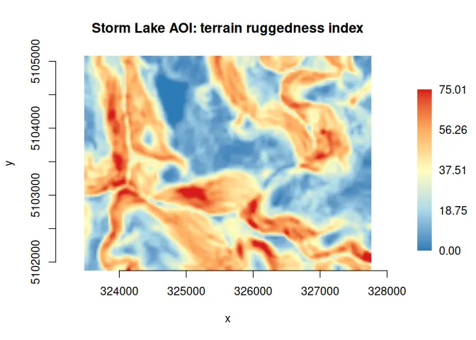

```r
# Visualize terrain ruggedness index (TRI)
system.file("extdata/storml_elev.tif", package="gdalraster") |>
  gdal_run_piped("raster tri", "", "MEM") |>
  plot_raster(legend = TRUE,
              minmax_pct_cut = c(0, 99),
              col_map_fn = rev(ltc::ltc("heatmap3")),
              main = "Storm Lake AOI: terrain ruggedness index")
```

## GDAL CLI in an R native pipeline `|>`

Using in-memory GDAL datasets (MEM):

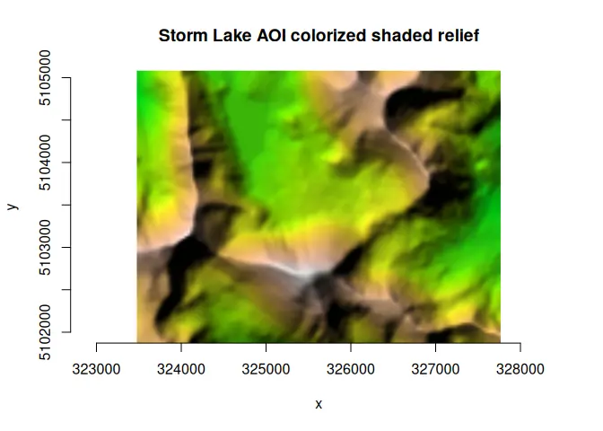

```r
f_elev |>
  gdal_run_piped("raster color-map", "", "MEM",
    list(color_map = f_pal)
  ) |>
  gdal_run_piped("raster blend", "", "MEM",
    list(operator = "hsv-value",
         overlay =
           gdal_run_piped(f_elev, "raster hillshade", "", "MEM",
             list(zfactor = 1.5)))
  ) |>
  plot_raster(main = "Storm Lake AOI colorized shaded relief")
```

# Wrap Up

Stable and well tested

On CRAN since May 2023

Focused project

Tracking upstream development

## 💙 Made by hand w/ love & care 💙

**https://github.com/firelab/gdalraster**

### Huge thanks GEOS

[figure not shown]